# MSc_CW2_13172387_F_Neziri

Florian Neziri

05/01/2019

#### 1. Bayesian Networks and Naïve Bayes Classiﬁer

Let: Y = Buys Computer, X1 = Income, X2 = Student, X3 = Credit Rating.

###### (a) Given a training dataset including 30 instances and a Bayesian network indicating the relationships between 3 features (i.e. Income, Student and Credit Rate), and the class attribute (i.e. Buy Computer), please create the conditional probability tables by hand.

**Y - Buys Computer:**

| Y=1, Yes | Y=0, No |
| --- | --- |
| 0.467 | 0.533 |

**X1 – Income:**

|  | X1=1, High | X1=0, Low |
| --- | --- | --- |
| Y=1 | 0.357 | 0.643 |
| Y=0 | 0.4375 | 0.5625 |

**X2 – Student:**

|  | X1=1, True | X1=0, False |
| --- | --- | --- |
| Y=1 | 0.500 | 0.500 |
| Y=0 | 0.6875 | 0.3125 |

**X3 - Credit Rating:**

|  | X3=1, Excellent | X3=0, Fair |
| --- | --- | --- |
| Y=1, X1=1, X2=1 | 0.500 | 0.500 |
| Y=1, X1=1, X2=0 | 0.667 | 0.333 |
| Y=1, X1=0, X2=1 | 0.400 | 0.600 |
| Y=1, X1=0, X2=0 | 0.500 | 0.500 |
| Y=0, X1=1, X2=1 | 0.500 | 0.500 |
| Y=0, X1=1, X2=0 | 0.667 | 0.333 |
| Y=0, X1=0, X2=1 | 0.286 | 0.714 |
| Y=0, X1=0, X2=0 | 0.500 | 0.500 |

###### (b) Make predictions for 2 testing instances by using the Bayesian network classiﬁer.

**Instance 31:**

- Income = Low, X1=0
- Student = False, X2=0
- Credit Rating = Excellent, X3=1
- Buys Computer = ?, Y=?

P(Y|X1, X2, X3) ∝ P(X1, X2, X3, Y) = P(X3|X2, X1, Y)P(X2|Y)P(X1|Y)P(Y)

Y=1:

P(Y=1|X1=0, X2=0, X3=1) ∝ P(X1=0, X2=0, X3=1, Y=1) =  
P(X3=1|X2=0, X1=0, Y=1)P(X2=0|Y=1)P(X1=0|Y=1)P(Y=1) =  
0.500 * 0.500 * 0.643 * 0.467 = 0.075

Y=0:

P(Y=0|X1=0, X2=0, X3=1) ∝ P(X1=0, X2=0, X3=1, Y=0) =  
P(X3=1|X2=0, X1=0, Y=0)P(X2=0|Y=0)P(X1=0|Y=0)P(Y=0) =  
0.500 * 0.3125 * 0.5625 * 0.533 = 0.047

As 0.075 (Y=1) > 0.046875 (Y=0): for Instance 31, **Y=1, Buys Computer = Yes**

**Instance 32:**

- Income = High, X1=1
- Student = False, X2=0
- Credit Rating = Fair, X3=0
- Buys Computer = ?, Y=?

P(Y|X1, X2, X3) ∝ P(X1, X2, X3, Y) = P(X3|X2, X1, Y)P(X2|Y)P(X1|Y)P(Y)

Y=1:

P(Y=1|X1=1, X2=0, X3=0) ∝ P(X1=1, X2=0, X3=0, Y=1) =  
P(X3=0|X2=0, X1=1, Y=1)P(X2=0|Y=1)P(X1=1|Y=1)P(Y=1) =  
0.333 * 0.357 * 0.500 * 0.467 = 0.028

Y=0:

P(Y=0|X1=1, X2=0, X3=0) ∝ P(X1=1, X2=0, X3=0, Y=0) =  
P(X3=0|X2=0, X1=1, Y=0)P(X2=0|Y=0)P(X1=1|Y=0)P(Y=0) =  
0.333 * 0.4375 * 0.3125 * 0.533 = 0.024

As 0.028 (Y=1) > 0.024 (Y=0): for Instance 32, **Y=1, Buys Computer = Yes**

###### (c) Based on the conditional independence assumption between features, please create the conditional probability tables by hand.

**Y - Buys Computer:**

| Y=1, Yes | Y=0, No |
| --- | --- |
| 0.467 | 0.533 |

**X1 – Income:**

|  | X1=1, High | X1=0, Low |
| --- | --- | --- |
| Y=1 | 0.357 | 0.643 |
| Y=0 | 0.4375 | 0.5625 |

**X2 – Student:**

|  | X1=1, True | X1=0, False |
| --- | --- | --- |
| Y=1 | 0.500 | 0.500 |
| Y=0 | 0.6875 | 0.3125 |

**X3 - Credit Rating:**

|  | X1=1, Excellent | X1=0, Fair |
| --- | --- | --- |
| Y=1 | 0.500 | 0.500 |
| Y=0 | 0.4375 | 0.5625 |

###### (d) Make predictions for 2 testing instances by using the naïve Bayes classiﬁer.

**Instance 31:**

- Income = Low, X1=0
- Student = False, X2=0
- Credit Rating = Excellent, X3=1
- Buys Computer = ?, Y=?

P(Y|X1, X2, X3) ∝ P(X1, X2, X3, Y) = P(X3|Y)P(X2|Y)P(X1|Y)P(Y)

Y=1:

P(Y=1|X1=0, X2=0, X3=1) ∝ P(X1=0, X2=0, X3=1, Y=1) =  
P(X3=1|Y=1)P(X2=0|Y=1)P(X1=0|Y=1)P(Y=1) =  
0.500 * 0.500 * 0.643 * 0.467 = 0.075

Y=0:

P(Y=0|X1=0, X2=0, X3=1) ∝ P(X1=0, X2=0, X3=1, Y=0) =  
P(X3=1|Y=0)P(X2=0|Y=0)P(X1=0|Y=0)P(Y=0) =  
0.4375 * 0.3125 * 0.5625 * 0.533 = 0.041

As 0.075 (Y=1) > 0.041 (Y=0): for Instance 31, **Y=1, Buys Computer = Yes**

**Instance 32:**

- Income = High, X1=1
- Student = False, X2=0
- Credit Rating = Fair, X3=0
- Buys Computer = ?, Y=?

P(Y|X1, X2, X3) ∝ P(X1, X2, X3, Y) = P(X3|Y)P(X2|Y)P(X1|Y)P(Y)

Y=1:

P(Y=1|X1=1, X2=0, X3=0) ∝ P(X1=1, X2=0, X3=0, Y=1) =  
P(X3=0|Y=1)P(X2=0|Y=1)P(X1=1|Y=1)P(Y=1) =  
0.500 * 0.500 * 0.357 * 0.467 = 0.042

Y=0:

P(Y=0|X1=1, X2=0, X3=0) ∝ P(X1=1, X2=0, X3=0, Y=0) =  
P(X3=0|Y=0)P(X2=0|Y=0)P(X1=1|Y=0)P(Y=0) =  
0.4375 * 0.3125 * 0.5625 * 0.533 = 0.041

As 0.042 (Y=1) > 0.041 (Y=0): for Instance 32, **Y=1, Buys Computer = Yes**

#### 2. Decision Trees and Random Forest

To predict room occupancy using the decision tree classiﬁcation algorithm.

###### (a) Load the room occupancy data and train a decision tree classiﬁer. Evaluate the predictive performance by reporting the accuracy obtained on the testing dataset.

```
##
## Classification tree:
## tree(formula = Occupancy ~ ., data = occupancy.train)
## Variables actually used in tree construction:
## [1] "Light"       "Temperature" "CO2"         "Humidity"
## Number of terminal nodes:  6
## Residual mean deviance:  0.07156 = 142.7 / 1994
## Misclassification error rate: 0.0125 = 25 / 2000
```

```
##          occupancy.testing
## tree.pred  No Yes
##       No  195  16
##       Yes  45  44
```

The test error rate is 0.2033333 (20.3%).

###### (b) Output and analyse the tree learned by the decision tree algorithm, i.e. plot the tree structure and make a discussion about it.

```
## node), split, n, deviance, yval, (yprob)
##       * denotes terminal node
##
##  1) root 2000 2362.00 No ( 0.72250 0.27750 )
##    2) Light < 162.875 1381    0.00 No ( 1.00000 0.00000 ) *
##    3) Light > 162.875 619  411.60 Yes ( 0.10339 0.89661 )
##      6) Temperature < 22.2113 333   75.47 Yes ( 0.02402 0.97598 ) *
##      7) Temperature > 22.2113 286  282.90 Yes ( 0.19580 0.80420 )
##       14) CO2 < 893.125 56   73.00 No ( 0.64286 0.35714 )
##         28) Humidity < 26.695 39   21.15 No ( 0.92308 0.07692 ) *
##         29) Humidity > 26.695 17    0.00 Yes ( 0.00000 1.00000 ) *
##       15) CO2 > 893.125 230  135.90 Yes ( 0.08696 0.91304 )
##         30) Temperature < 22.6417 196    0.00 Yes ( 0.00000 1.00000 ) *
##         31) Temperature > 22.6417 34   46.07 No ( 0.58824 0.41176 ) *
```

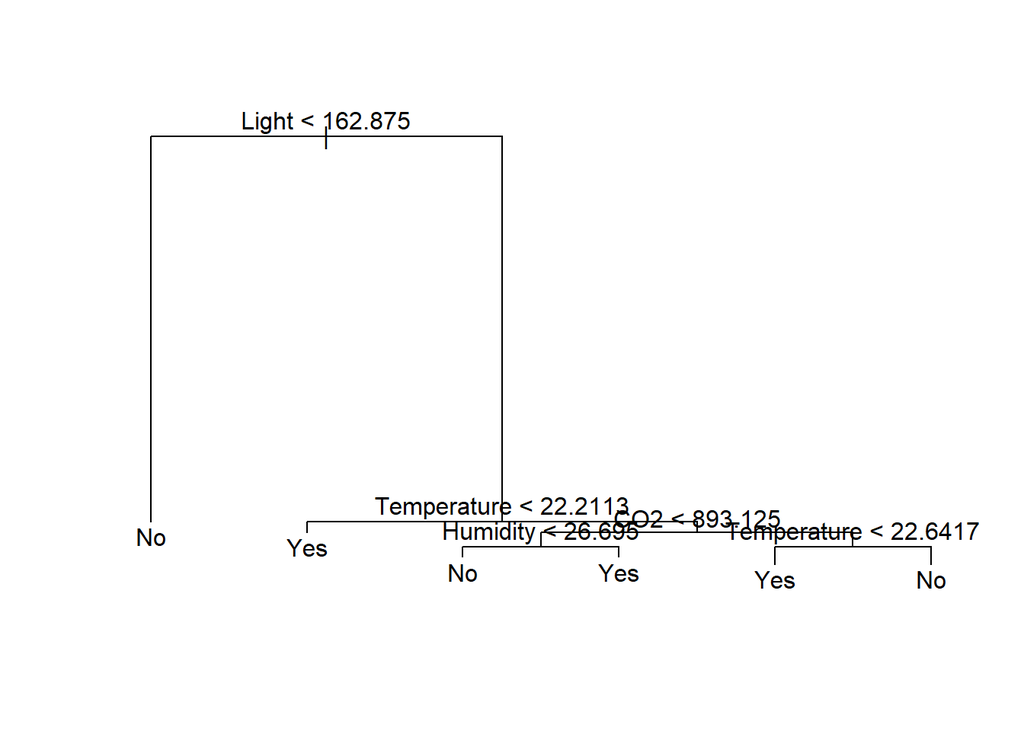

Let us see if pruning the tree will obtain better results:

```
## $size
## [1] 6 5 2 1
##
## $dev
## [1]  33  42  65 555
##
## $k
## [1] -Inf    6   11  491
##
## $method
## [1] "misclass"
##
## attr(,"class")
## [1] "prune"         "tree.sequence"
```

We can see that the cv error rate is lowest when there are 6 nodes and, since we had 6 nodes in our original tree, there is no need to prune the tree.

###### (c) Train a random forests classiﬁer, and evaluate the predictive performance by reporting the accuracy obtained on the testing dataset.

```
##                  occupancy.testing
## rf.occupancy.pred  No Yes
##               No  173   6
##               Yes  67  54
```

The test error rate is 0.2433333 (24.3%).

###### (d) Output and analyse the feature importance obtained by the random forests classifier.

```
##                      No      Yes MeanDecreaseAccuracy MeanDecreaseGini
## Temperature   12.554322 10.23127             16.40444        101.45487
## Humidity       8.096317 11.90900             14.25695         27.44461
## Light         29.634118 45.90122             46.32397        422.60371
## CO2            8.586178 15.04623             16.02932        206.35507
## HumidityRatio  7.148994 11.55380             14.45179         42.65080
```

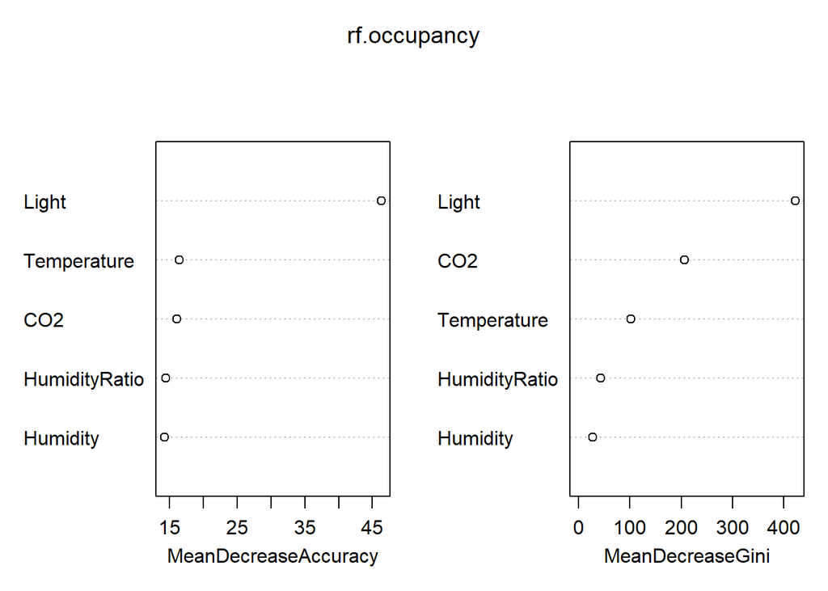

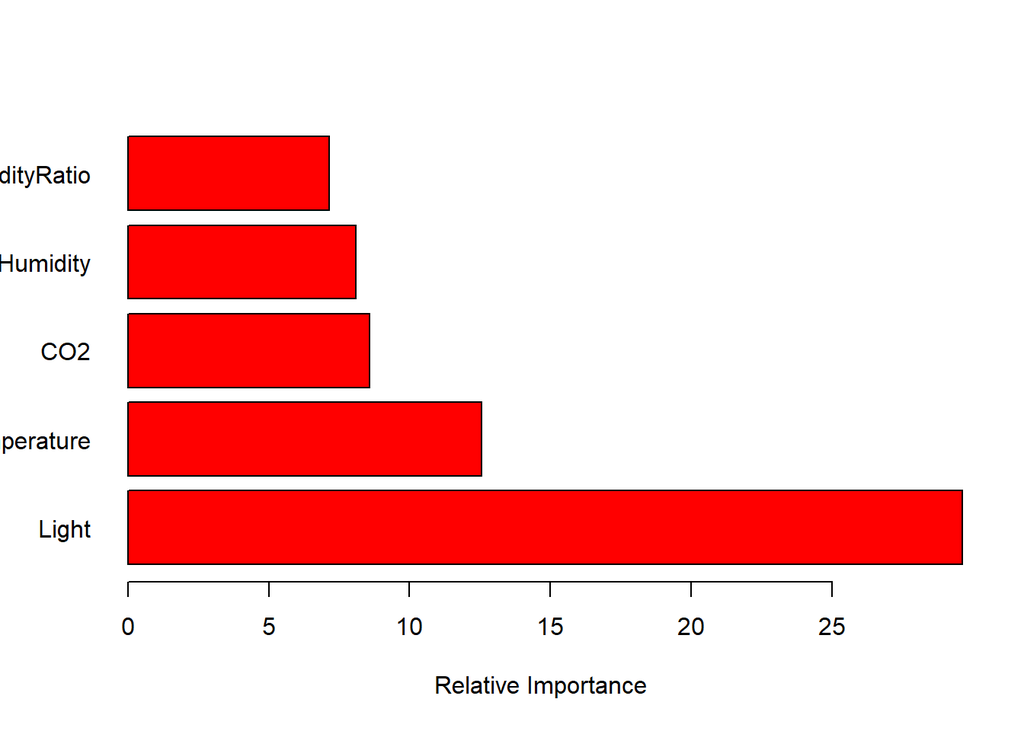

Light is by the far the most important variable in determing Room Occupancy. The mean decrease in accuracy is roughly 3 times larger when excluding the light variable compared to any other variable.

The mean decrease in Gini is also largest for light, meaning that the nodes resulting from the light variable have a higher purity and therefore makes light the most important variable in this random forest model.

#### 3. SVM

To predict the wine quality using the support vector machine classification algorithm.

###### (a) Download the wine quality data and use the training dataset to conduct the grid-search to find the optimal hyperparameters of svm by using the linear kernel.

```
##
## Parameter tuning of 'svm':
##
## - sampling method: 10-fold cross validation
##
## - best parameters:
##  cost gamma
##     1  0.01
##
## - best performance: 0.2416667
##
## - Detailed performance results:
##     cost gamma     error dispersion
## 1   0.01  0.01 0.2460000 0.01293860
## 2   0.10  0.01 0.2430000 0.01888562
## 3   1.00  0.01 0.2416667 0.02019962
## 4   5.00  0.01 0.2416667 0.01951574
## 5  10.00  0.01 0.2420000 0.01982641
## 6   0.01  0.03 0.2460000 0.01293860
## 7   0.10  0.03 0.2430000 0.01888562
## 8   1.00  0.03 0.2416667 0.02019962
## 9   5.00  0.03 0.2416667 0.01951574
## 10 10.00  0.03 0.2420000 0.01982641
## 11  0.01  0.10 0.2460000 0.01293860
## 12  0.10  0.10 0.2430000 0.01888562
## 13  1.00  0.10 0.2416667 0.02019962
## 14  5.00  0.10 0.2416667 0.01951574
## 15 10.00  0.10 0.2420000 0.01982641
## 16  0.01  0.50 0.2460000 0.01293860
## 17  0.10  0.50 0.2430000 0.01888562
## 18  1.00  0.50 0.2416667 0.02019962
## 19  5.00  0.50 0.2416667 0.01951574
## 20 10.00  0.50 0.2420000 0.01982641
## 21  0.01  1.00 0.2460000 0.01293860
## 22  0.10  1.00 0.2430000 0.01888562
## 23  1.00  1.00 0.2416667 0.02019962
## 24  5.00  1.00 0.2416667 0.01951574
## 25 10.00  1.00 0.2420000 0.01982641
```

###### (b) Train a svm classifier by using the linear kernel and the corresponding optimal hyperparameters, then make predictions on the testing dataset, report the predictive performance.

```
##
## Call:
## svm(formula = quality ~ ., data = wine.train, kernel = "linear",
##     gamma = 0.1, cost = 1)
##
##
## Parameters:
##    SVM-Type:  C-classification
##  SVM-Kernel:  linear
##        cost:  1
##
## Number of Support Vectors:  1710
##
##  ( 855 855 )
##
##
## Number of Classes:  2
##
## Levels:
##  Bad Good
```

```
## [1] 0.3175
```

###### (c) Conduct the grid-search to find the optimal hyperparameters of svm by using the RBF kernel.

```
##
## Parameter tuning of 'svm':
##
## - sampling method: 10-fold cross validation
##
## - best parameters:
##  cost gamma
##     5     1
##
## - best performance: 0.158
##
## - Detailed performance results:
##     cost gamma     error dispersion
## 1   0.01  0.01 0.2853333 0.02144185
## 2   0.10  0.01 0.2530000 0.01300047
## 3   1.00  0.01 0.2370000 0.01543205
## 4   5.00  0.01 0.2133333 0.02255309
## 5  10.00  0.01 0.2083333 0.02326710
## 6   0.01  0.03 0.2643333 0.01707283
## 7   0.10  0.03 0.2433333 0.01677741
## 8   1.00  0.03 0.2150000 0.02223611
## 9   5.00  0.03 0.2016667 0.02889957
## 10 10.00  0.03 0.1993333 0.02693385
## 11  0.01  0.10 0.2686667 0.01860572
## 12  0.10  0.10 0.2100000 0.01911628
## 13  1.00  0.10 0.1946667 0.02889743
## 14  5.00  0.10 0.1833333 0.02884612
## 15 10.00  0.10 0.1803333 0.03040671
## 16  0.01  0.50 0.5096667 0.01426815
## 17  0.10  0.50 0.2310000 0.02582228
## 18  1.00  0.50 0.1643333 0.02484768
## 19  5.00  0.50 0.1626667 0.02083444
## 20 10.00  0.50 0.1666667 0.02509242
## 21  0.01  1.00 0.5126667 0.01015923
## 22  0.10  1.00 0.2200000 0.05621827
## 23  1.00  1.00 0.1606667 0.02112865
## 24  5.00  1.00 0.1580000 0.01744126
## 25 10.00  1.00 0.1593333 0.01698220
```

The optimal hyperparameters for the radial kernel are: cost = 5, gamma = 1.

###### (d) Train a svm classifier by using the RBF kernel and the corresponding optimal hyperparameters, then make predictions on the testing dataset, report the predictive performance.

```
##
## Call:
## svm(formula = quality ~ ., data = wine.train, kernel = "radial",
##     gamma = 1, cost = 5)
##
##
## Parameters:
##    SVM-Type:  C-classification
##  SVM-Kernel:  radial
##        cost:  5
##
## Number of Support Vectors:  2205
##
##  ( 1084 1121 )
##
##
## Number of Classes:  2
##
## Levels:
##  Bad Good
```

```
## [1] 0.3625
```

###### (e) Conduct the ROC curve analysis to compare the predictive performance of svm classifiers trained by using the linear and RBF kernels respectively.

*I can’t get the code to work for this question, but here is the code I wrote that kept giving me an error message:*

**First calculate AUROC Values:**

library(ROCR)

pr.lin.model <- prediction(svmfit.wine.lin.pred, wine.test$quality)  
auroc.lin.model <- performance(pr.lin.model, measure = “auc”)  
auroc.lin.model.value <- auroc.lin.model@y.values[[1]]

pr.rad.model <- prediction(svmfit.wine.rad.pred, wine.test$quality)  
auroc.rad.model <- performance(pr.rad.model, measure = “auc”)  
auroc.rad.model.value <- auroc.rad.model@y.values[[1]]

**Then plot the ROC Curves:**

prf.lin.model <- performance(pr.lin.model, measure = “tpr”, x.measure = “fpr”)  
prf.rad.model <- performance(pr.rad.model, measure = “tpr”, x.measure = “fpr”)

plot(prf.lin.model, col=“blue”)  
legend(0.3,0.4,  
c(text=sprintf(‘AUROC (Linear kernel) = %s’,  
round(auroc.lin.model.value, digits=3))),  
lty=1, cex=0.9, bty=“n”, col = c(“blue”),  
y.intersp=1, inset=c(0.1,-0.15))

plot(prf.rad.model, col=“red”)  
legend(0.3,0.3,  
c(text=sprintf(‘AUROC (RBF Kernel) = %s’,  
round(auroc.rad.model.value, digits=3))),  
lty=1, cex=0.9, bty=“n”, col = c(“red”),  
y.intersp=1, inset=c(0.1,-0.15))

abline(a = 0, b = 1)

#### 4. Hierarchical Clustering

Consider the USArrests data. We will now perform hierarchical clustering on the states.

###### (a) Using hierarchical clustering with complete linkage and Euclidean distance, cluster the states.

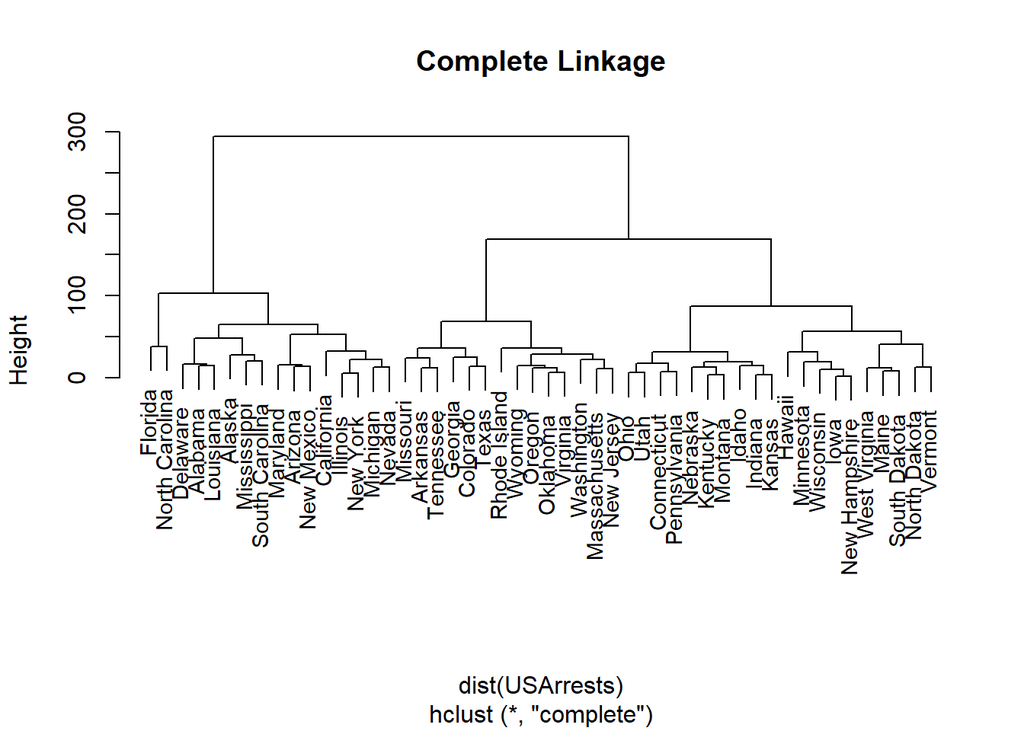

###### (b) Cut the dendrogram at a height that results in three distinct clusters. Which states belong to which clusters?

```
##        Alabama         Alaska        Arizona       Arkansas     California
##              1              1              1              2              1
##       Colorado    Connecticut       Delaware        Florida        Georgia
##              2              3              1              1              2
##         Hawaii          Idaho       Illinois        Indiana           Iowa
##              3              3              1              3              3
##         Kansas       Kentucky      Louisiana          Maine       Maryland
##              3              3              1              3              1
##  Massachusetts       Michigan      Minnesota    Mississippi       Missouri
##              2              1              3              1              2
##        Montana       Nebraska         Nevada  New Hampshire     New Jersey
##              3              3              1              3              2
##     New Mexico       New York North Carolina   North Dakota           Ohio
##              1              1              1              3              3
##       Oklahoma         Oregon   Pennsylvania   Rhode Island South Carolina
##              2              2              3              2              1
##   South Dakota      Tennessee          Texas           Utah        Vermont
##              3              2              2              3              3
##       Virginia     Washington  West Virginia      Wisconsin        Wyoming
##              2              2              3              3              2
```

###### (c) Hierarchically cluster the states using complete linkage and Euclidean distance, after scaling the variables to have standard deviation one.

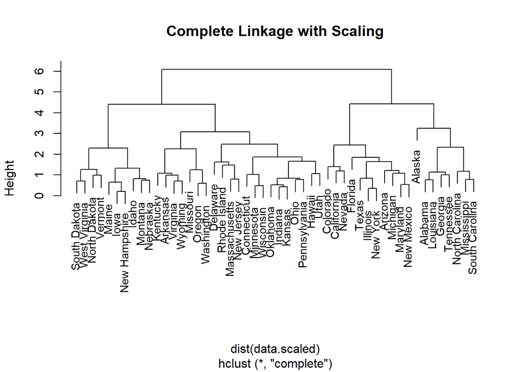

###### (d) What effect does scaling the variables have on the hierarchical clustering obtained? In your opinion, should the variables be scaled before the inter-observation dissimilarities are computed? Provide a justification for your answer.

```
##        Alabama         Alaska        Arizona       Arkansas     California
##              1              1              2              3              2
##       Colorado    Connecticut       Delaware        Florida        Georgia
##              2              3              3              2              1
##         Hawaii          Idaho       Illinois        Indiana           Iowa
##              3              3              2              3              3
##         Kansas       Kentucky      Louisiana          Maine       Maryland
##              3              3              1              3              2
##  Massachusetts       Michigan      Minnesota    Mississippi       Missouri
##              3              2              3              1              3
##        Montana       Nebraska         Nevada  New Hampshire     New Jersey
##              3              3              2              3              3
##     New Mexico       New York North Carolina   North Dakota           Ohio
##              2              2              1              3              3
##       Oklahoma         Oregon   Pennsylvania   Rhode Island South Carolina
##              3              3              3              3              1
##   South Dakota      Tennessee          Texas           Utah        Vermont
##              3              1              2              3              3
##       Virginia     Washington  West Virginia      Wisconsin        Wyoming
##              3              3              3              3              3
```

```
##
##      1  2  3
##   1  6  9  1
##   2  2  2 10
##   3  0  0 20
```

22 out of the 50 are clustered into different classes after scaling so the variables should be scaled beforehand. This is also because the variables have are measured on different scales. For examples, the murder rate is never higher than 17.4, whereas assault never fall below 45 but can be as high as 337.

#### 5. PCA and K-Means Clustering

In this problem, you will generate simulated data, and then perform PCA and K-means clustering on the data.

###### (a) Generate a simulated data set with 20 observations in each of three classes (i.e. 60 observations total), and 50 variables.

###### (b) Perform PCA on the 60 observations and plot the first two principal components’ eigenvector. Use a different color to indicate the observations in each of the three classes. If the three classes appear separated in this plot, then continue on to part (c). If not, then return to part (a) and modify the simulation so that there is greater separation between the three classes. Do not continue to part (c) until the three classes show at least some separation in the first two principal component eigenvectors.

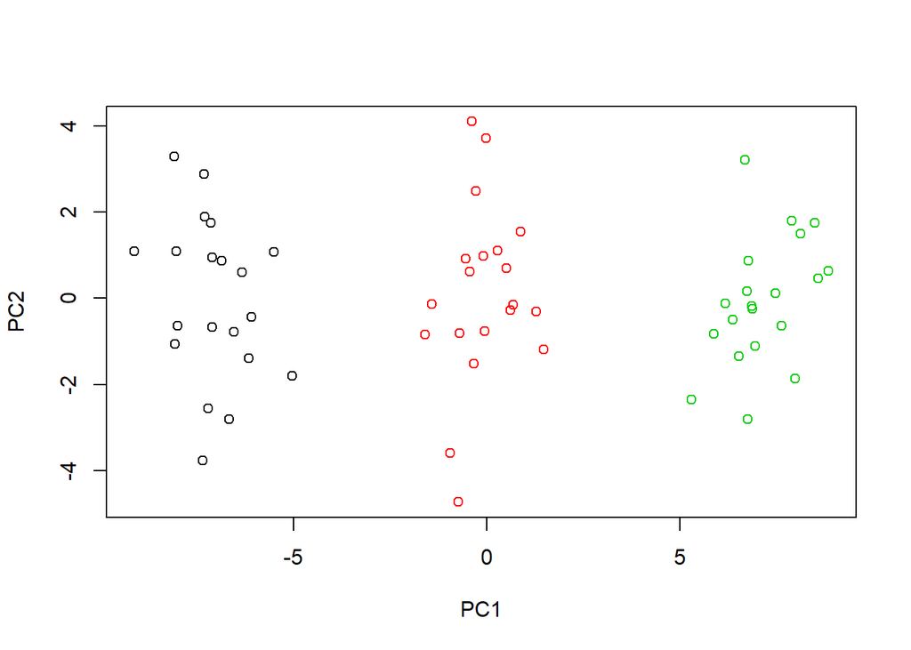

###### (c) Perform K-means clustering of the observations with K = 3. How well do the clusters that you obtained in K-means clustering compare to the true class labels?

```
##    true_class_labels
##      1  2  3
##   1  0  0 20
##   2  0 20  0
##   3 20  0  0
```

All observations are clustered perfectly.

###### (d) Perform K-means clustering with K = 2. Describe your results.

```
##    true_class_labels
##      1  2  3
##   1  0  0 20
##   2 20 20  0
```

All the observations from one of the clusters are combined into a different cluster.

###### (e) Now perform K-means clustering with K = 4, and describe your results.

```
##    true_class_labels
##      1  2  3
##   1 20  0  0
##   2  0  0 13
##   3  0  0  7
##   4  0 20  0
```

The third cluster is split into two other clusters.

###### (f) Now perform K-means clustering with K = 3 on the first two principal components, rather than on the raw data. That is, perform K-means clustering on the 60 × 2 matrix of which the first column is the first principal component’s corresponding eigenvector, and the second column is the second principal component’s corresponding eigenvector. Comment on the results.

```
##    true_class_labels
##      1  2  3
##   1  0  0 20
##   2 20  0  0
##   3  0 20  0
```

All of the observations are clustered perfeclty which is the same as when we performed k-means clustering with k=3 on the raw data.

###### (g) Using the scale() function, perform K-means clustering with K = 3 on the data after scaling each variable to have standard deviation one. How do these results compare to the true class labels? Will the scaling affect the clustering?

```
##    true_class_labels
##      1  2  3
##   1  0  0 20
##   2  0 20  0
##   3 20  0  0
```

All observations are clustered perfectly, just as with unscaled variables.